# SNIC Segmentation Pipeline

## Pipeline overview

The Simple Non-Iterative Clustering (SNIC) algorithm grows superpixels from an initial set of seed pixels. A typical workflow is:

1. Load or prepare an image cube with one or more spectral bands.
2. Place seeds with one of the `snic_grid()` helpers.
3. Call `snic()` to segment the image using the chosen compactness.
4. Inspect the result or convert it to polygons for further analysis.

This vignette walks through that pipeline by working with the Sentinel-2 subset shipped with the package and highlights the most important parameters.

## Loading imagery with terra

```r
if (requireNamespace("terra", quietly = TRUE)) {
  library(terra)

  data_dir <- system.file("S2-20LMR", package = "snic", mustWork = TRUE)
  band_names <- c("S2_20LMR_B02_20220630.tif",
                  "S2_20LMR_B04_20220630.tif",
                  "S2_20LMR_B08_20220630.tif",
                  "S2_20LMR_B12_20220630.tif")
  s2 <- rast(file.path(data_dir, band_names))

  # Aggregate raster for lightweight examples
  s2_small <- aggregate(s2, fact = 6)
  s2_small
} else {
  stop("Package 'terra' is required for this example.")
}
```

```
#> class       : SpatRaster
#> size        : 128, 171, 4  (nrow, ncol, nlyr)
#> resolution  : 120, 120  (x, y)
#> extent      : 429960, 450480, 9046000, 9061360  (xmin, xmax, ymin, ymax)
#> coord. ref. : WGS 84 / UTM zone 20S (EPSG:32720)
#> source(s)   : memory
#> names       :        B02,        B04,       B08,         B12
#> min values  : 0.01911111, 0.01588889, 0.0120000, 0.002444444
#> max values  : 0.45388889, 0.43211111, 0.5425556, 0.438777778
```

`terra::rast()` reads the reference bands and stores them as a `SpatRaster`.

## Understanding `snic()` parameters

The `snic()` interface is intentionally minimal:

- `img`: array or `SpatRaster` containing the bands to segment.
- `seeds`: pixel coordinates that anchor cluster growth. They must be supplied explicitly, which keeps the results reproducible.
- `compactness`: non-negative value that balances spectral similarity and spatial proximity. Smaller numbers privilege spectral contrast, whereas larger ones grow rounder segments.

The default compactness value of `1` offers a good starting point on reflectance-scaled data. Images with different value ranges can be re-scaled before segmentation (see `?terra::scale`).

## Seed placement with `snic_grid_rect()`

`snic_grid_rect()` builds a uniform rectangular grid of seeds. Two arguments control the layout:

- `spacing`: expected distance (in pixels) between neighboring seeds. A single value applies to rows and columns equally; a length-two vector defines anisotropic spacing.
- `padding`: margin from the image borders where seeds are not placed. The default (`spacing / 2`) centers the grid inside the scene.

```r
spacing_demo <- 30L
seeds_default <- snic_grid_rect(s2_small, spacing = spacing_demo)
head(seeds_default)
```

```
#>           r  c       lat      long
#> 1  16.00000 16 -8.507880 -63.61948
#> 2  48.33333 16 -8.542612 -63.61953
#> 3  80.66667 16 -8.578429 -63.61959
#> 4 113.00000 16 -8.613161 -63.61965
#> 5  16.00000 51 -8.507939 -63.58132
#> 6  48.33333 51 -8.542671 -63.58137
```

As `spacing` increases the number of seeds decreases. Use `snic_count_seeds()` to estimate how many seeds will be created without actually generating them:

```r
seed_total <- snic_count_seeds(
  s2_small,
  spacing = spacing_demo,
  padding = spacing_demo / 2
)
seed_total
```

```
#> [1] 20
```

Padding creates inner margins and can be set independently along rows and columns:

```r
seeds_asymmetric <- snic_grid_rect(
  s2_small,
  spacing = c(30, 20),
  padding = c(10, 5)
)
nrow(seeds_asymmetric)
```

```
#> [1] 36
```

## End-to-end segmentation example

```r
comp <- 0.25
seg_rect <- snic(
  s2_small,
  seeds = seeds_default,
  compactness = comp
)
seg_rect
```

```
#> class       : SpatRaster
#> size        : 128, 171, 1  (nrow, ncol, nlyr)
#> resolution  : 120, 120  (x, y)
#> extent      : 429960, 450480, 9046000, 9061360  (xmin, xmax, ymin, ymax)
#> coord. ref. : WGS 84 / UTM zone 20S (EPSG:32720)
#> source(s)   : memory
#> name        : snic
#> min value   :    1
#> max value   :   19
```

Overlay the segmentation to inspect the results:

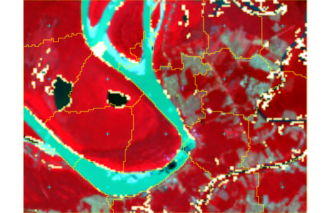

```r
snic_plot(
  s2_small,
  r = 3, g = 2, b = 1,
  stretch = "lin",
  seeds = seeds_default,
  seg = seg_rect,
  seg_plot_args = list(border = "#FFFF00", col = NA, lwd = 0.6),
  seeds_plot_args = list(pch = 3, col = "#00FFFF", cex = 0.7)
)
```

The compactness parameter gently constrains the shapes of the superpixels. Combining a carefully chosen spacing and padding with compactness controls how detailed the segmentation becomes. Dedicated vignettes cover parameter tuning, seed placement strategies, non-Earth-observation imagery, and parallel processing for more advanced workflows.